# Analyzing LLMC outputs

# Goal

The goal of this notebook is to perform some analysis of results.

# Load data

```r
library(tidyverse)
evals <- read_csv("processed/llm-confidence-correct.csv")
life_eval <- read_csv("processed/life_eval.csv")
evals <- evals %>%
  bind_rows(
    life_eval %>%
      select(-min_age, -width) %>%
      mutate(question_id = as.character(question_id)) %>%
      rename(correct = prob)
    )
```

We give shorter names to the Qsets and LLMs.

```r
evals <- evals %>%
  mutate(
    qset = case_match(
      qset,
      "boolq_valid" ~ "BoolQ",
      "lsat_ar_test" ~ "LSAT",
      "sat_en" ~ "SAT",
      "sciq_test" ~ "SciQ",
      "halu_eval_qa" ~ "HaluEval",
      "life_eval" ~ "LifeEval"
      ),
    llm = case_match(
      llm,
      "Meta-Llama-3.1-70B-Instruct" ~ "Llama-70B",
      "Meta-Llama-3.1-8B-Instruct" ~ "Llama-8B",
      "claude-3-7-sonnet-20250219" ~ "Claude-Sonnet-3.7",
      "claude-3-haiku-20240307" ~ "Claude-Haiku-3",
      "claude-sonnet-4-20250514" ~ "Claude-Sonnet-4",
      "deepseek-r1" ~ "DeepSeek-R1",
      "deepseek-v3" ~ "DeepSeek-V3",
      "gpt-4o" ~ "GPT-4o",
      "o3-2025-04-16" ~ "GPT-o3",
      "gemini-2.5-flash" ~ "Gemini-2.5-Flash",
      "gemini-2.5-pro" ~ "Gemini-2.5-Pro"
    ))
life_eval <- life_eval %>%
  mutate(
    llm = case_match(
      llm,
      "Meta-Llama-3.1-70B-Instruct" ~ "Llama-70B",
      "Meta-Llama-3.1-8B-Instruct" ~ "Llama-8B",
      "claude-3-7-sonnet-20250219" ~ "Claude-Sonnet-3.7",
      "claude-3-haiku-20240307" ~ "Claude-Haiku-3",
      "claude-sonnet-4-20250514" ~ "Claude-Sonnet-4",
      "deepseek-r1" ~ "DeepSeek-R1",
      "deepseek-v3" ~ "DeepSeek-V3",
      "gpt-4o" ~ "GPT-4o",
      "o3-2025-04-16" ~ "GPT-o3",
      "gemini-2.5-flash" ~ "Gemini-2.5-Flash",
      "gemini-2.5-pro" ~ "Gemini-2.5-Pro"
    ))
```

# Restricting to a common set of questions

For each Qset, we restrict to a common set of questions that all LLMs answered. This is to avoid introducing bias whereby an LLM tends to give poorly formatted answers for hard questions and thereby gets evaluated on easier questions than other LLMs.

```r
questions_all_answered <- evals %>%
  count(qset,question_id) %>%
  filter(n == 11) %>%
  transmute(q_id = paste(qset, question_id, sep = "-"))
evals_common <- evals %>%
  filter(paste(qset, question_id, sep = "-") %in% questions_all_answered$q_id)
```

Originally, this is the number of questions per set:

```r
evals %>%
  distinct(qset, question_id) %>%
  count(qset)
```

```
## # A tibble: 6 × 2
##   qset         n
##   <chr>    <int>
## 1 BoolQ     3270
## 2 HaluEval  2000
## 3 LSAT       230
## 4 LifeEval   808
## 5 SAT        206
## 6 SciQ      1000
```

After filtering to questions where every LLM gave an answer, here is the new number of questions per set:

```r
evals_common %>%
  distinct(qset, question_id) %>%
  count(qset)
```

```
## # A tibble: 6 × 2
##   qset         n
##   <chr>    <int>
## 1 BoolQ     2503
## 2 HaluEval  1790
## 3 LSAT        86
## 4 LifeEval   751
## 5 SAT        173
## 6 SciQ       995
```

How much is each LLM responsible for not answering certain questions?

```r
evals %>%
  count(llm, qset) %>%
  pivot_wider(id_cols =  llm, names_from = qset, values_from = n)
```

```
## # A tibble: 11 × 7
##    llm               BoolQ HaluEval  LSAT LifeEval   SAT  SciQ
##    <chr>             <int>    <int> <int>    <int> <int> <int>
##  1 Claude-Haiku-3     3036     1855   230      808   180   999
##  2 Claude-Sonnet-3.7  3267     2000   228      808   206   999
##  3 Claude-Sonnet-4    3258     2000   188      808   205  1000
##  4 DeepSeek-R1        3214     2000   228      808   206  1000
##  5 DeepSeek-V3        2898     2000   228      808   204  1000
##  6 GPT-4o             3247     2000   230      808   206  1000
##  7 GPT-o3             3070     1991   193      761   205  1000
##  8 Gemini-2.5-Flash   3261     2000   177      808   206  1000
##  9 Gemini-2.5-Pro     3190     1984   188      807   204  1000
## 10 Llama-70B          3241     1960   208      807   202  1000
## 11 Llama-8B           3200     1997   190      800   202   997
```

# Calibration, accuracy

We compute the quantities that are in Table 1.

To compute ECE, we stratify questions into $M=10$ confidence bins:

$$Q_m = \bigl\{i\in Q: \frac{m-1}{M} < C_i (\hat{y_i })\leq
\frac{m}{M} \bigr\}$$

We then define

$$\text{ECE}(Q) = \frac{1}{|Q|}\sum_{m=1}^M n_m \cdot \,\bigl|
\text{accuracy}(Q_m) - \text{confidence}(Q_m)\bigr|$$

```r
stated_calib <- evals_common %>%
  mutate(confidence_bin = cut(stated_confidence, breaks = 10)) %>%
  group_by(qset, llm, confidence_bin) %>%
  summarize(
    confidence = mean(stated_confidence),
    accuracy = mean(correct),
    avg_gini = mean(stated_gini),
    num = n(),
    se_confidence = sd(stated_confidence) / sqrt(num),
    se_accuracy = sd(correct) / sqrt(num),
    .groups = "drop")
```

We export to `table1-info.csv` all the quantities shown in Table 1.

```r
table1 <- stated_calib %>%
  group_by(qset, llm) %>%
  summarize(
    num_tot = sum(num),
    ece = sum(num * abs(accuracy - confidence)) / num_tot,
    accuracy = sum(num * accuracy) / num_tot, # equivalent to doing mean(correct) on evals
    confidence = sum(num * confidence) / num_tot, # equivalent to doing mean(confidence) on evals
    avg_gini = sum(num * avg_gini) / num_tot, # equivalent to doing mean(stated_gini) on evals
    overconfidence = confidence - accuracy,
    .groups = "drop")
table1
```

```
## # A tibble: 66 × 8
##    qset  llm          num_tot    ece accuracy confidence avg_gini overconfidence
##    <chr> <chr>          <int>  <dbl>    <dbl>      <dbl>    <dbl>          <dbl>
##  1 BoolQ Claude-Haik…    2503 0.118     0.781      0.898   0.180          0.116
##  2 BoolQ Claude-Sonn…    2503 0.124     0.831      0.956   0.0772         0.124
##  3 BoolQ Claude-Sonn…    2503 0.0801    0.843      0.920   0.133          0.0767
##  4 BoolQ DeepSeek-R1     2503 0.111     0.845      0.956   0.0817         0.111
##  5 BoolQ DeepSeek-V3     2503 0.102     0.829      0.929   0.124          0.100
##  6 BoolQ GPT-4o          2503 0.0799    0.853      0.933   0.122          0.0796
##  7 BoolQ GPT-o3          2503 0.0440    0.861      0.826   0.271         -0.0347
##  8 BoolQ Gemini-2.5-…    2503 0.148     0.845      0.993   0.0131         0.148
##  9 BoolQ Gemini-2.5-…    2503 0.145     0.849      0.993   0.0122         0.145
## 10 BoolQ Llama-70B       2503 0.124     0.786      0.906   0.156          0.120
## # ℹ 56 more rows
```

```r
if (!dir.exists("analysis")) dir.create("analysis")
write_csv(table1, file = "analysis/table1-info.csv")
```

```r
table1 %>%
  pivot_longer(c(num_tot:confidence, overconfidence), names_to = "metric", values_to = "value") %>%
  filter(metric != "confidence") %>%
  pivot_wider(id_cols = c(qset, metric), names_from = llm, values_from = value) %>%
  write_csv(file = "analysis/table1-similar-layout.csv")
```

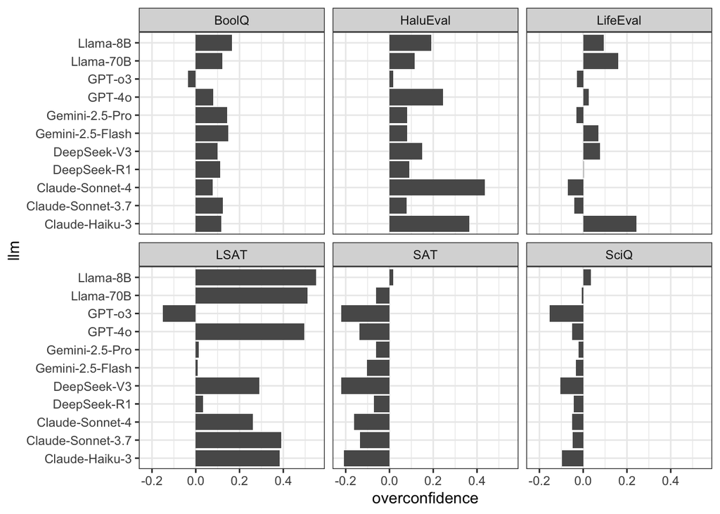

```r
table1 %>%
  ggplot(aes(y=llm, x=overconfidence)) +
  geom_col(position = "dodge") +
  facet_wrap(~ qset) +
  theme_bw()
```

## Calibration plots

Here I only show a point if at least 10 responses went into it.

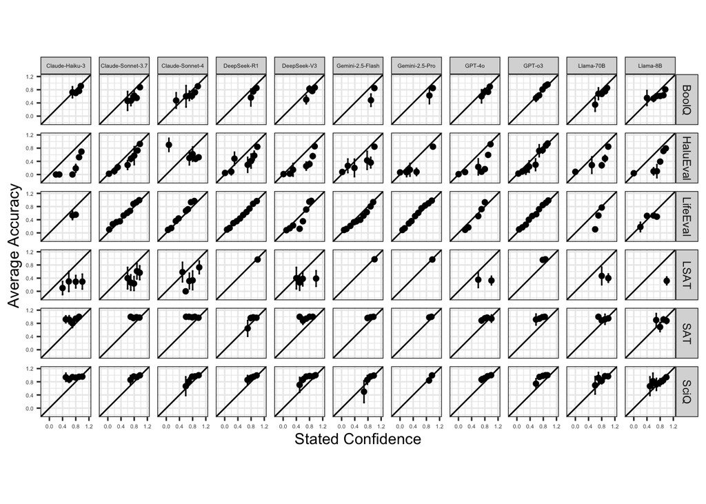

```r
stated_calib %>%
  filter(num >= 10) %>%
  ggplot(aes(x = confidence, y = accuracy)) +
  geom_point() +
  geom_errorbar(aes(ymax = accuracy + 2 * se_accuracy, ymin = accuracy - 2 * se_accuracy)) +
  geom_errorbarh(aes(xmax = confidence + 2 * se_confidence, xmin = confidence - 2 * se_confidence)) +
  geom_abline(slope = 1, intercept = 0) +
  facet_grid(qset ~ llm) +
  coord_equal() + xlim(-0.2,1.2) + ylim(-0.2,1.2) +
  theme_bw() +
  theme(
    strip.text.x = element_text(size = 4), # For horizontal facet labels
    strip.text.y = element_text(size = 8),  # For vertical facet labels
    axis.text = element_text(size = 4)
  ) +
  labs(x = "Stated Confidence", y = "Average Accuracy")
```

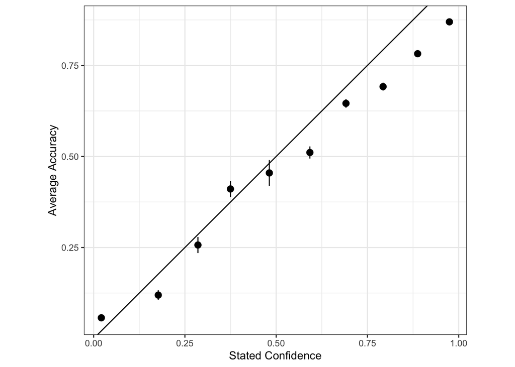

```r
evals_common %>%
  mutate(confidence_bin = cut(stated_confidence, breaks = 10)) %>%
  group_by(confidence_bin) %>%
  summarize(
    confidence = mean(stated_confidence),
    accuracy = mean(correct),
    num = n(),
    se_confidence = sd(stated_confidence) / sqrt(num),
    se_accuracy = sd(correct) / sqrt(num),
    .groups = "drop") %>%
  filter(num >= 10) %>%
  ggplot(aes(x = confidence, y = accuracy)) +
  geom_point() +
  geom_pointrange(aes(ymax = accuracy + 2 * se_accuracy, ymin = accuracy - 2 * se_accuracy)) +
  geom_abline(slope = 1, intercept = 0) +
  theme_bw() +
  coord_equal() +
  labs(x = "Stated Confidence", y = "Average Accuracy")
```

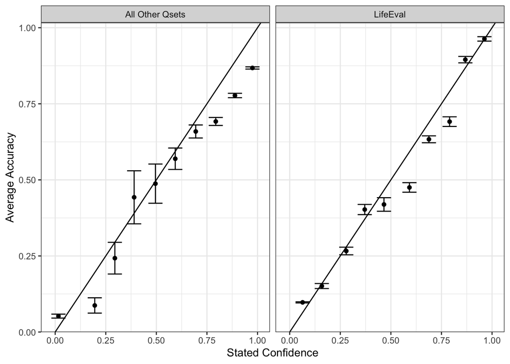

```r
evals_common %>%
  mutate(confidence_bin = cut(stated_confidence, breaks = 10)) %>%
  mutate(life_eval = if_else(qset == "LifeEval", "LifeEval", "All Other Qsets")) %>%
  group_by(confidence_bin, life_eval) %>%
  summarize(
    confidence = mean(stated_confidence),
    accuracy = mean(correct),
    num = n(),
    se_confidence = sd(stated_confidence) / sqrt(num),
    se_accuracy = sd(correct) / sqrt(num),
    .groups = "drop") %>%
  filter(num >= 10) %>%
  ggplot(aes(x = confidence, y = accuracy)) +
  geom_point() +
  geom_errorbar(aes(ymax = accuracy + 2 * se_accuracy, ymin = accuracy - 2 * se_accuracy)) +
  geom_abline(slope = 1, intercept = 0) +
  facet_wrap(~ life_eval) +
  theme_bw() +
  labs(x = "Stated Confidence", y = "Average Accuracy")
```

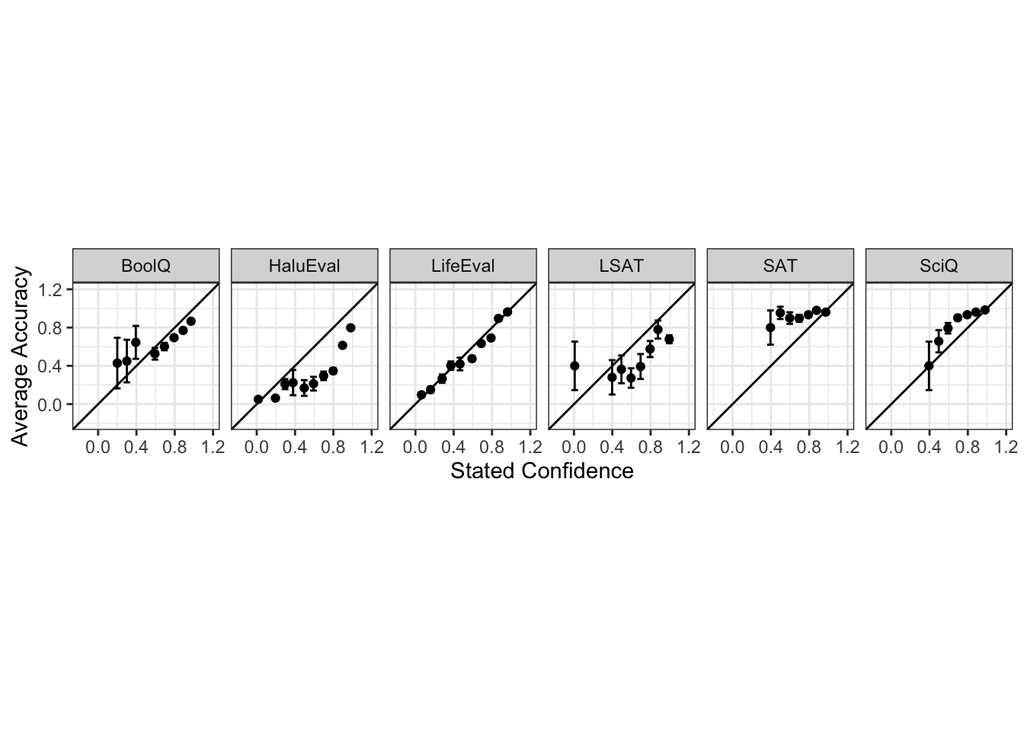

```r
evals_common %>%
  mutate(confidence_bin = cut(stated_confidence, breaks = 10)) %>%
  group_by(confidence_bin, qset) %>%
  summarize(
    confidence = mean(stated_confidence),
    accuracy = mean(correct),
    num = n(),
    se_confidence = sd(stated_confidence) / sqrt(num),
    se_accuracy = sqrt(accuracy * (1-accuracy)) / sqrt(num),
    .groups = "drop") %>%
  filter(num >= 10) %>%
  ggplot(aes(x = confidence, y = accuracy)) +
  geom_point() +
  geom_errorbar(aes(ymax = accuracy + 2 * se_accuracy, ymin = accuracy - 2 * se_accuracy)) +
  geom_errorbarh(aes(xmax = confidence + 2 * se_confidence, xmin = confidence - 2 * se_confidence)) +
  geom_abline(slope = 1, intercept = 0) +
  facet_grid(~ qset) +
  coord_equal() + xlim(-0.2,1.2) + ylim(-0.2,1.2) +
  theme_bw() +
  labs(x = "Stated Confidence", y = "Average Accuracy")
```

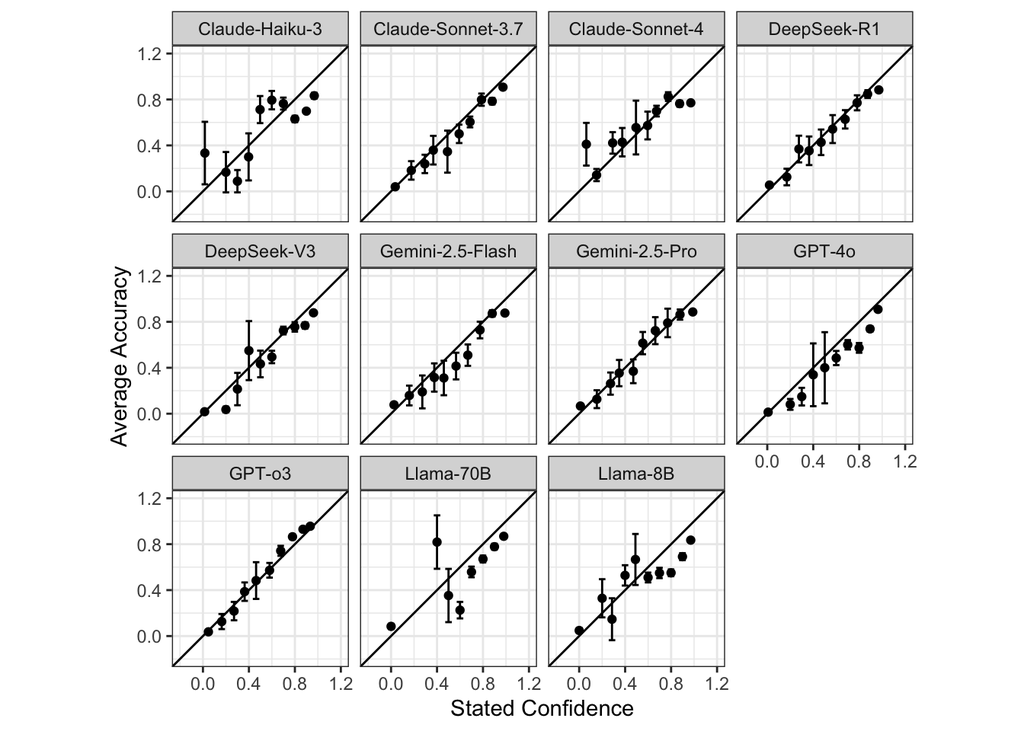

```r
evals_common %>%
  mutate(confidence_bin = cut(stated_confidence, breaks = 10)) %>%
  group_by(confidence_bin, llm) %>%
  summarize(
    confidence = mean(stated_confidence),
    accuracy = mean(correct),
    num = n(),
    se_confidence = sd(stated_confidence) / sqrt(num),
    se_accuracy = sqrt(accuracy * (1-accuracy)) / sqrt(num),
    .groups = "drop") %>%
  filter(num >= 10) %>%
  ggplot(aes(x = confidence, y = accuracy)) +
  geom_point() +
  geom_errorbar(aes(ymax = accuracy + 2 * se_accuracy, ymin = accuracy - 2 * se_accuracy)) +
  geom_errorbarh(aes(xmax = confidence + 2 * se_confidence, xmin = confidence - 2 * se_confidence)) +
  geom_abline(slope = 1, intercept = 0) +
  facet_wrap(~llm) +
  coord_equal() + xlim(-0.2,1.2) + ylim(-0.2,1.2) +
  theme_bw() +
  labs(x = "Stated Confidence", y = "Average Accuracy")
```

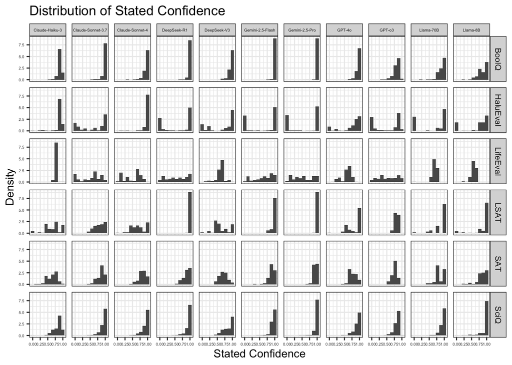

```r
evals_common %>%
  ggplot(aes(x=stated_confidence, y = after_stat(density))) +
  geom_histogram(bins=10) +
  facet_grid(qset ~ llm) +
  theme_bw() +
  theme(
    strip.text.x = element_text(size = 4), # For horizontal facet labels
    strip.text.y = element_text(size = 8),  # For vertical facet labels
    axis.text = element_text(size = 4)
  ) +
  labs(x = "Stated Confidence", y = "Density", title = "Distribution of Stated Confidence")
```

## Stated vs. token confidence

For the two Llama models, we get token-probability-based confidence in addition to stated confidence. We can compare the two.

```r
stated_token <- evals_common %>%
  filter(!is.na(chosen_token_confidence)) %>%
  mutate(stated_confidence_bin = cut(stated_confidence, breaks = 10)) %>%
  group_by(qset, llm, stated_confidence_bin) %>%
  summarize(
    avg_stated_confidence = mean(stated_confidence),
    avg_token_confidence = mean(chosen_token_confidence),
    accuracy = mean(correct),
    num = n(),
    se_stated_conf = sd(stated_confidence) / sqrt(num),
    se_token_conf = sd(chosen_token_confidence) / sqrt(num),
    .groups = "drop")
```

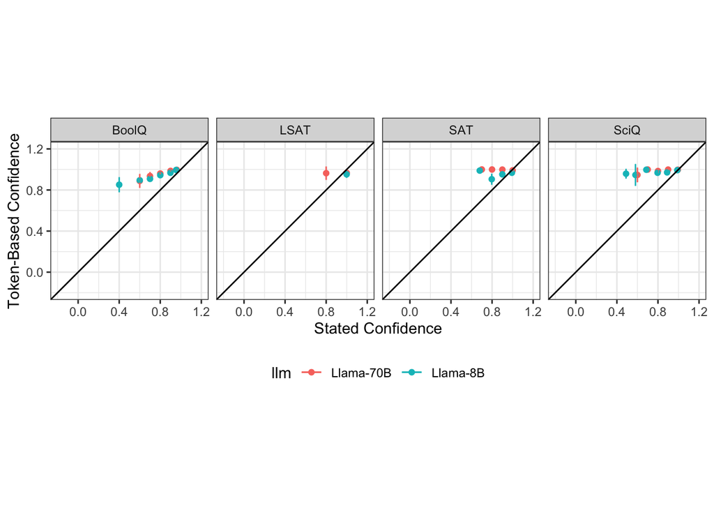

```r
stated_token %>%
  filter(num >= 10) %>%
  ggplot(aes(x = avg_stated_confidence, y = avg_token_confidence, color = llm)) +
  geom_point() +
  geom_errorbar(aes(ymax = avg_token_confidence + 2 * se_token_conf,
                    ymin = avg_token_confidence - 2 * se_token_conf)) +
  geom_errorbarh(aes(xmax = avg_stated_confidence + 2 * se_stated_conf,
                     xmin = avg_stated_confidence - 2 * se_stated_conf)) +
  geom_abline(slope = 1, intercept = 0) +
  facet_grid(~ qset) +
  coord_equal() + xlim(-0.2,1.2) + ylim(-0.2,1.2) +
  theme_bw() +
  theme(legend.position = "bottom") +
  labs(x = "Stated Confidence", y = "Token-Based Confidence")
```

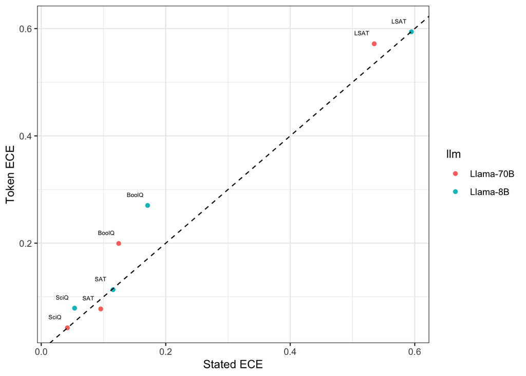

```r
stated_token %>%
  group_by(qset, llm) %>%
  summarize(
    num_tot = sum(num),
    ece_stated = sum(num * abs(accuracy - avg_stated_confidence)) / num_tot,
    ece_token = sum(num * abs(accuracy - avg_token_confidence)) / num_tot,
    .groups = "drop") %>%
  ggplot(aes(x=ece_stated, y=ece_token)) +
  geom_point(aes(color = llm)) +
  geom_text(aes(label = qset), size = 2, nudge_y=0.02, nudge_x=-0.02) +
  geom_abline(slope = 1, intercept = 0, linetype = "dashed") +
  labs(x = "Stated ECE", y = "Token ECE") +
  theme_bw()
```

## LifeEval

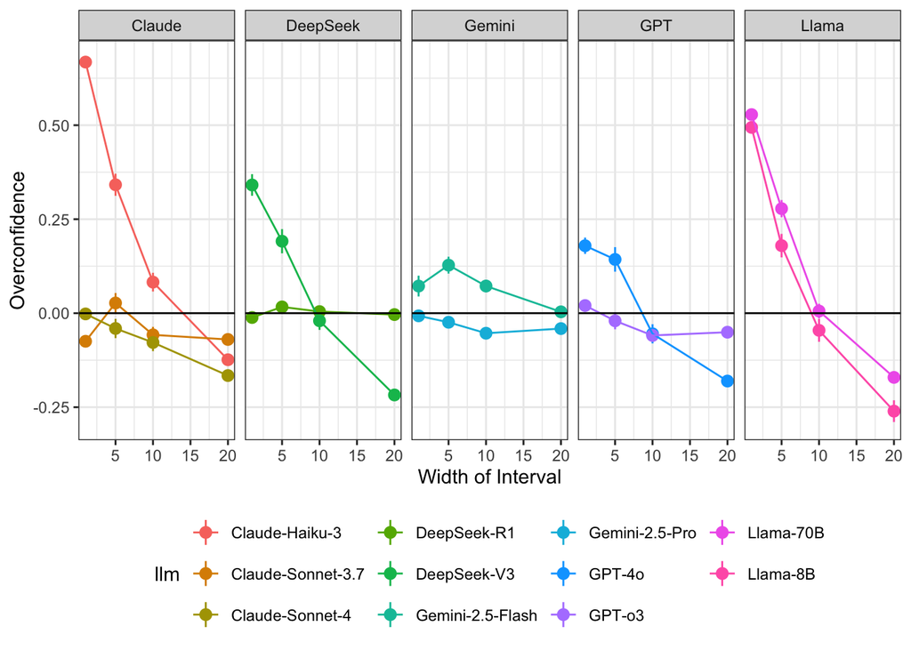

```r
life_eval %>%
  group_by(llm, width) %>%
  summarize(
    overconfidence = mean(stated_confidence - prob),
    se_overconfidence = sd(stated_confidence - prob) / sqrt(n()),
    .groups = "drop") %>%
  mutate(`Model Family` = str_extract(llm, "^[^-]+")) %>%
  ggplot(aes(x=width,y=overconfidence, color = llm)) +
  geom_point() +
  geom_pointrange(aes(ymin = overconfidence - 2 * se_overconfidence,
                    ymax = overconfidence + 2 * se_overconfidence)) +
  geom_line() +
  facet_grid(~`Model Family`) +
  geom_hline(yintercept = 0) +
  theme_bw() +
  theme(legend.position = "bottom") +
  labs(x = "Width of Interval", y = "Overconfidence")
```